# Cancer: The Timeless and Deadly Disease

Manny Bettencourt, Aryan Patel, Aarush Bedi

2025-02-25

## Introduction

We all know someone close to us who has been affected by cancer in their lifetime. And in recent times, the cancer statistics that we come across have been extremely alarming. For instance, according to the National Cancer Institute, over 40% of Americans will be diagnosed with cancer during their lifetimes (USAFacts). Recognizing the significance that this condition will impose on the health and well being for the coming generations, we decided to gain a deeper understanding of it. Using Emory’s Library resources we decided to leverage two datasets about Cancer Incidence and Mortality that were originally published in the US Cancer Statistics Database.

The datasets primarily consist of cancer statistics across different states in the US from the year 1999 to 2021. These datasets were specifically of interest to us because they allowed us to identify similarities and differences between US states’ cancer incidence and prevalence. These datasets also enabled us to identify any possible trends in incidence and mortality of cancer over the years, and whether certain years had a higher cancer prevalence in any of the US states. We would also be interested in exploring any correlations between the mortalities and incidences across all states and years. While the data in our exploratory analysis limits our findings to solely correlation, we anticipate future studies to build upon our work and look into the specific cancer types and sex, for example, in controlled experiments to possibly find causation. For instance, if a specific cancer type is found to have a strong correlation with cancer-related mortalities, research on the potential causation between these variables should be conducted which can then be furthered by finding potential solutions to limit exposure to carcinogens for the specific cancer type.

## Sourcing Data from Emory’s Library Databases

As mentioned above, the two combined datasets from the US Cancer Statistics Database allowed us to create a massive dataset with the following columns - State, Cancer Type, Sex, Year, Incidence Count and Mortality Count. We soon realized that it would not be possible to directly compare the incidence counts and mortality counts across all the states. Since each state has a very different population count, bigger states like California and Texas would be overrepresented in our analysis. To control for the differences in population, we wanted to calculate and analyze incidence and mortality rates as a percentage of the states’ total population. In order to do this, we had to manually integrate 52 datasets using the excel files from the US Census Bureau that included population statistics based on sex for the years 2000 to 2010 (US Census Bureau). This manual integration was completed by extracting the values from each of the sheets and placing them into a new excel sheet titled “masterpopulationbystatesbysex.csv”. This process was true for every year except 1999 which did not have population data that was split based on sex, which is why it was excluded. For the years 2011-19 and 2020-21, there were datasets that included all the necessary data for each of the states in a single dataset, respectively, which was directly imported (US Census Bureau). The final step was to merge all the different dataframes into one, giving us a master dataset that included the following columns - State, Year, Incidence, Mortality and Population.

After downloading and creating the files explained above, we loaded in the data as well the necessary packages to begin manipulating the data into a format that will reflect our exploratory analysis. The only package that we will be using for this analysis is `tidyverse`.

```r
#First we must load in the necessary packages
library("tidyverse")
#Next we must read in the data: both the cancer incidence and mortality, and then the state populations
Incidence <- read_csv("../data/CancerIncidencebySexfromtheU.S.CancerStatisticsDatabase.csv")
Mortality <- read_csv("../data/CancerMortalitybySexfromtheU.S.CancerStatisticsDatabase.csv")
populationdata19992010<-read_csv("../data/masterpopulationbystatesbysex.csv")
populationdata20112019<-read_csv("../data/sc-est2019-agesex-civ.csv")
populationdata20202023<-read_csv("../data/sc-est2023-agesex-civ.csv")
```

## Distinguishing Variables and Their Types Within the Data

After the data has been read into a tabular format, we can begin to dissect the architecture of each table. By breaking down the aspects of variable names and variable types, we will gain a further understanding on how to merge the datasets together and how they are related to each other in order to get a more cohesive exploration.

```r
#We must check the structure of each of the datasets and parse through the types of variables
head(Incidence)
```

```
## # A tibble: 6 × 921
##   State     Brain and Other Nerv…¹ Brain and Other Nerv…² Breast, Incidence, M…³
##   <chr>                      <dbl>                  <dbl>                  <dbl>
## 1 Californ…                   1367                   1066                    208
## 2 Florida                     1035                    816                    191
## 3 Texas                       1014                    724                    134
## 4 New York                     769                    613                    158
## 5 Pennsylv…                    580                    445                     83
## 6 Illinois                     478                    365                    117
## # ℹ abbreviated names:
## #   ¹`Brain and Other Nervous System, Incidence, Male, 2021`,
## #   ²`Brain and Other Nervous System, Incidence, Female, 2021`,
## #   ³`Breast, Incidence, Male, 2021`
## # ℹ 917 more variables: `Breast, Incidence, Female, 2021` <dbl>,
## #   `Cervix Uteri, Incidence, Female, 2021` <dbl>,
## #   `Colon and Rectum, Incidence, Male, 2021` <dbl>, …
```

```r
head(Mortality)
```

```
## # A tibble: 6 × 921
##   State     Brain and Other Nerv…¹ Brain and Other Nerv…² Breast, Deaths, Male…³
##   <chr>                      <dbl>                  <dbl>                  <dbl>
## 1 Californ…                   1184                    858                     40
## 2 Florida                      765                    589                     38
## 3 Texas                        727                    549                     40
## 4 New York                     523                    408                     27
## 5 Pennsylv…                    456                    351                     30
## 6 Illinois                     393                    286                     23
## # ℹ abbreviated names: ¹`Brain and Other Nervous System, Deaths, Male, 2021`,
## #   ²`Brain and Other Nervous System, Deaths, Female, 2021`,
## #   ³`Breast, Deaths, Male, 2021`
## # ℹ 917 more variables: `Breast, Deaths, Female, 2021` <dbl>,
## #   `Cervix Uteri, Deaths, Female, 2021` <dbl>,
## #   `Colon and Rectum, Deaths, Male, 2021` <dbl>,
## #   `Colon and Rectum, Deaths, Female, 2021` <dbl>, …
```

```r
head(populationdata19992010)
```

```
## # A tibble: 6 × 5
##   State    Year `Male Population` `Female Population` `Total Population`
##   <chr>   <dbl>             <dbl>               <dbl>              <dbl>
## 1 Alabama  1999                NA                  NA                  0
## 2 Alabama  2000           2149338             2302835            4452173
## 3 Alabama  2001           2158138             2309496            4467634
## 4 Alabama  2002           2165719             2314370            4480089
## 5 Alabama  2003           2179422             2324069            4503491
## 6 Alabama  2004           2192872             2337857            4530729
```

```r
head(populationdata20112019)
```

```
## # A tibble: 6 × 18
##   SUMLEV REGION DIVISION STATE NAME     SEX   AGE ESTBASE2010_CIV POPEST2010_CIV
##   <chr>   <dbl>    <dbl> <dbl> <chr>  <dbl> <dbl>           <dbl>          <dbl>
## 1 010         0        0     0 Unite…     0     0         3944160        3951430
## 2 010         0        0     0 Unite…     0     1         3978090        3957730
## 3 010         0        0     0 Unite…     0     2         4096939        4090621
## 4 010         0        0     0 Unite…     0     3         4119051        4111688
## 5 010         0        0     0 Unite…     0     4         4063186        4077346
## 6 010         0        0     0 Unite…     0     5         4056872        4064521
## # ℹ 9 more variables: POPEST2011_CIV <dbl>, POPEST2012_CIV <dbl>,
## #   POPEST2013_CIV <dbl>, POPEST2014_CIV <dbl>, POPEST2015_CIV <dbl>,
## #   POPEST2016_CIV <dbl>, POPEST2017_CIV <dbl>, POPEST2018_CIV <dbl>,
## #   POPEST2019_CIV <dbl>
```

```r
head(populationdata20202023)
```

```
## # A tibble: 6 × 12
##   SUMLEV REGION DIVISION STATE NAME     SEX   AGE ESTBASE2020_CIV POPEST2020_CIV
##   <chr>   <dbl>    <dbl> <dbl> <chr>  <dbl> <dbl>           <dbl>          <dbl>
## 1 010         0        0     0 Unite…     0     0         3734587        3702966
## 2 010         0        0     0 Unite…     0     1         3777056        3764198
## 3 010         0        0     0 Unite…     0     2         3873233        3853792
## 4 010         0        0     0 Unite…     0     3         3966159        3933140
## 5 010         0        0     0 Unite…     0     4         4049207        4037779
## 6 010         0        0     0 Unite…     0     5         4077558        4074339
## # ℹ 3 more variables: POPEST2021_CIV <dbl>, POPEST2022_CIV <dbl>,
## #   POPEST2023_CIV <dbl>
```

Summary of Data Structures:

Incidence - This dataset provides the cancer incidence counts for specified populations. Each variable represents a specific population based on the type of cancer, the year, the sex, and incidence. Each observation in the dataset then signifies the count of incidences for that specified population.

Mortality - Similarly, this dataset provides the cancer mortality counts for specified populations. Just like the Incidence dataset, each variable represents a specific population based on the type of cancer, the year, the sex, and mortality. Each observation in the dataset signifies the count of mortalities for that specified population.

populationdata19992010 - The variables of interest that are present in this dataset are Male Popultion, Female population, Year and State. Both the Population variables of interest each denote the male and female population respectively for each state in a given year.

populationdata20112019 - The variables of interest in this dataset are Name which denotes the name of the state, Sex which denotes the sex of the population, and POPEST{year}_CIV where year =[2011,2019] which denotes the year for that population.

populationdata20202023 - Similar to the populationdata20112019 dataset the variables of interest are the NAME, SEX and POPEST{year}_CIV where year =[2020,2023], which all share the same description as the variables found in the populationdata20112019.

Merging Importance: We must know and keep into account the formatting of the columns and the variable values themselves in order to ensure a seamless merging process.

Important Note on Population Data from US Census: For all of the population data obtained from the US Census Bureau, we use their estimated population counts which the Bureau derived using a formula that takes into account a population base, migration trends, and past growth trends for a given state.

## Restructuring the Data to Broaden the Scope of the Exploratory Analysis

We must change the current data structures of the tables, in order for them to be merged and analyzed together. This will provide a more fruitful exploratory analysis as opposed to just parsing the summary statics of few variable from differing datasets that have no correlation to each other.

### Incidence and Mortality tables

Given the current data structure of the Incidence and Mortality tables, we will not be able to perform any meaningful analysis as the variables are in a format that doesn’t separate the cancer type, the year, the sex, or incidence/mortality. Therefore to get more detailed variables, we must break it down into separate variables like CancerType, Sex, MortalityCount/IncidenceCount, and Year using the pivot longer.

Another note is that some of the cancer types, like urinary cancer, have a comma in their name, which would cause problems in the presented method of separation. Therefore, the comma was removed.

```r
#Now we must convert our datasets into a long format rather than a wide format before performing any data analysis and also change the name of the urinary cancer to make the data easier to handle.

IncidenceLong <- Incidence %>%
  pivot_longer(., cols = -State,names_to = "CancerTypeIncidenceSexYear", values_to = "IncidenceCount") %>%
  mutate(CancerTypeIncidenceSexYear= sub("^Urinary Bladder, invasive and in situ,","Urinary Bladder invasive and in situ,", CancerTypeIncidenceSexYear)) %>%
  separate(CancerTypeIncidenceSexYear, into = c("CancerType", "Incidence","Sex","Year"),sep=",")

MortalityLong <- Mortality %>%
  pivot_longer(., cols = -State,names_to = "CancerTypeMortalitySexYear", values_to = "MortalityCount") %>%
  mutate(CancerTypeMortalitySexYear= sub("^Urinary Bladder, invasive and in situ,","Urinary Bladder invasive and in situ,", CancerTypeMortalitySexYear)) %>%
  separate(CancerTypeMortalitySexYear, into = c("CancerType", "Mortality","Sex","Year"),sep=",")


#Since there is a variable in each of the datasets that is just Incidence and Mortality repeating we can remove those columns

IncidenceLong<-IncidenceLong[,-3]

MortalityLong<-MortalityLong[,-3]


#Check that both of the datasets have a single variable per column and there should only be 5 columns now ("State","CancerType","Sex","Year","Count")

str(IncidenceLong)
```

```
## tibble [47,840 × 5] (S3: tbl_df/tbl/data.frame)
##  $ State         : chr [1:47840] "California" "California" "California" "California" ...
##  $ CancerType    : chr [1:47840] "Brain and Other Nervous System" "Brain and Other Nervous System" "Breast" "Breast" ...
##  $ Sex           : chr [1:47840] " Male" " Female" " Male" " Female" ...
##  $ Year          : chr [1:47840] " 2021" " 2021" " 2021" " 2021" ...
##  $ IncidenceCount: num [1:47840] 1367 1066 208 29995 1430 ...
```

```r
str(MortalityLong)
```

```
## tibble [47,840 × 5] (S3: tbl_df/tbl/data.frame)
##  $ State         : chr [1:47840] "California" "California" "California" "California" ...
##  $ CancerType    : chr [1:47840] "Brain and Other Nervous System" "Brain and Other Nervous System" "Breast" "Breast" ...
##  $ Sex           : chr [1:47840] " Male" " Female" " Male" " Female" ...
##  $ Year          : chr [1:47840] " 2021" " 2021" " 2021" " 2021" ...
##  $ MortalityCount: num [1:47840] 1184 858 40 4474 459 ...
```

After checking the successful creation of the variables we can now have a description for each one of the new variables. We do have two datasets at the moment but the only difference between them is that one looks at incidence counts and the other looks at mortality counts, the rest of the variables are the same

State - This will provide the state for a given count.

CancerType - This will provide the type of the cancer for a given count.

Sex - This is will provide the sex for a given count.

Year - This will provide the year for a given count.

IncidenceCount - This will provide the number of incidences in a given year, for a given sex, in a given state, and for a give cancer type.

MortalityCount - This will provide the number of mortalities in a given year, for a given sex, in a given state, and for a give cancer type.

Since we will be making comparisons between mortality and incidence across other variables, we will join the two datasets into one. After the merge is complete between incidence and mortality, we will broaden our scope by collapsing the table to get the sum of incidences and mortalities for a given state, sex and year grouping. Essentially this new table will be irrespective of CancerType, a variable that could potentially be examined later in a confirmatory analysis.

```r
#Given that we want to compare the incidence of cancer with the mortality of cancer, we will merge the two datasets into one

IncidenceandMortalityData<-left_join(IncidenceLong,MortalityLong,by=c("State","CancerType","Sex","Year"))


#Check to make sure the data structure is the same and that only the MortalityCount variable has been merged to the IncidenceLong dataset

str(IncidenceandMortalityData)
```

```
## tibble [47,840 × 6] (S3: tbl_df/tbl/data.frame)
##  $ State         : chr [1:47840] "California" "California" "California" "California" ...
##  $ CancerType    : chr [1:47840] "Brain and Other Nervous System" "Brain and Other Nervous System" "Breast" "Breast" ...
##  $ Sex           : chr [1:47840] " Male" " Female" " Male" " Female" ...
##  $ Year          : chr [1:47840] " 2021" " 2021" " 2021" " 2021" ...
##  $ IncidenceCount: num [1:47840] 1367 1066 208 29995 1430 ...
##  $ MortalityCount: num [1:47840] 1184 858 40 4474 459 ...
```

In order to collapse the data to get a resulting table that is irrespective of cancer type we must first group by the unique state, sex and year combinations (for example: Alabama Male 1999), and then sum the counts of incidences and mortalities across cancer types for each of the unique groupings

```r
#Collapse the data

IncidenceandMortalitybySexStateYear<-IncidenceandMortalityData%>%
  select(-CancerType)%>%
  group_by(State,Sex,Year)%>%
  summarise(Incidence = sum(IncidenceCount,na.rm = TRUE),
            Mortality = sum(MortalityCount,na.rm = TRUE),.groups = "drop")


#Making the variable types consistent across datasets

IncidenceandMortalitybySexStateYear$Year<-as.factor(IncidenceandMortalitybySexStateYear$Year)


#Ensure there are no extra spaces so that the values will match when merging

IncidenceandMortalitybySexStateYear$State <- trimws(IncidenceandMortalitybySexStateYear$State)

IncidenceandMortalitybySexStateYear$Sex <- trimws(IncidenceandMortalitybySexStateYear$Sex)

IncidenceandMortalitybySexStateYear$Year <- trimws(IncidenceandMortalitybySexStateYear$Year)


#Check to ensure the variables were correctly collapsed and that there is no longer a CancerType variable

summary(IncidenceandMortalitybySexStateYear)
```

```
##     State               Sex                Year             Incidence
##  Length:2392        Length:2392        Length:2392        Min.   :    0
##  Class :character   Class :character   Class :character   1st Qu.: 3747
##  Mode  :character   Mode  :character   Mode  :character   Median : 9450
##                                                           Mean   :13805
##                                                           3rd Qu.:16330
##                                                           Max.   :83390
##    Mortality
##  Min.   :    0
##  1st Qu.: 1237
##  Median : 3316
##  Mean   : 4820
##  3rd Qu.: 5869
##  Max.   :27038
```

As we see in the summary of the newly created IncidenceandMortalitybySexStateYear table, we have successfully made observations irrespective of CancerType.

### Population tables

After manipulating the data format of IncidenceandMortalitybySexStateYear we now have to clean and format the population data into a table that is suitable for merging into the IncidenceandMortalitybySexStateYear table.

```r
#We will not work with the Total Population column from the population dataset from 1999 - 2010 since we are interested in merging the population data into the IncidenceandMortalitybySexStateYear dataset

populationbysextable19992010 <- populationdata19992010%>%
  select(-'Total Population')


#We want to set the column names for the dataset to match values found in the IncidenceandMortalitybySexStateYear dataset

colnames(populationbysextable19992010)<-c("State","Year","Male","Female")


#Now we must convert our datasets into a long format rather than a wide format to properly continue with data analysis and name the variable stored in the column as "Sex"

populationbysextable19992010<-populationbysextable19992010%>%
  pivot_longer(!c(State,Year),names_to = "Sex", values_to = "Population")


#We want to convert Year column into a factor in order to make variable types consistent across datasets

populationbysextable19992010$Year<-as.factor(populationbysextable19992010$Year)
```

For the 2011-2019 and 2020-2023 population by sex tables, we want to select certain columns that will be of interest and filter for age = 999 to get the total count of the population irrespective of Age and Sex not equal to 0 to get the Male and Female populations, and recode the sex variable which was initially numerical into a factor where 1 = Male and 2 = Female

```r
#For 2020-2023 data we filter out the years that were not in out cancer data table, therefore we only retained the populations from 2020 to 2021 for that particular dataset

populationbysextable20112019 <- populationdata20112019%>%
  select(-c(SUMLEV,REGION,DIVISION,STATE,AGE,ESTBASE2010_CIV,POPEST2010_CIV))%>%
  filter(populationdata20112019$AGE==999,populationdata20202023$SEX != 0)%>%
  mutate(SEX=recode(SEX,`1`="Male",`2`="Female"))

populationbysextable20202021 <- populationdata20202023%>%
  select(-c(SUMLEV,REGION,DIVISION,STATE,AGE,ESTBASE2020_CIV,POPEST2022_CIV,POPEST2023_CIV))%>%
  filter(populationdata20202023$AGE==999,populationdata20202023$SEX != 0)%>%
  mutate(SEX=recode(SEX,`1`="Male",`2`="Female"))


#Renaming the columns to match values found in the IncidenceandMortalitybySexStateYear dataset

colnames(populationbysextable20112019)<-c("State","Sex","2011","2012","2013","2014","2015","2016","2017","2018","2019")

colnames(populationbysextable20202021)<-c("State","Sex","2020","2021")


#We must convert our datasets into a long format rather than a wide format by taking the column names and putting them into a Year variable and then the values (Population Counts)

populationbysextable20112019<-populationbysextable20112019%>%
  pivot_longer(!c(State,Sex),names_to = "Year", values_to = "Population")

populationbysextable20202021<-populationbysextable20202021%>%
  pivot_longer(!c(State,Sex),names_to = "Year", values_to = "Population")
```

Validate if the formatting of the tables has been done corectly by checking to see if the column names match from each populationbysextable to the column names found in the IncidenceandMortalitybySexStateYear data.

```r
#View the summary of each of the population tables

summary(populationbysextable19992010)
```

```
##     State                Year         Sex              Population
##  Length:1224        1999   :102   Length:1224        Min.   :  245327
##  Class :character   2000   :102   Class :character   1st Qu.:  765976
##  Mode  :character   2001   :102   Mode  :character   Median : 2060856
##                     2002   :102                      Mean   : 2898760
##                     2003   :102                      3rd Qu.: 3290241
##                     2004   :102                      Max.   :18736126
##                     (Other):612                      NA's   :102
```

```r
summary(populationbysextable20112019)
```

```
##     State               Sex                Year             Population
##  Length:936         Length:936         Length:936         Min.   :   277554
##  Class :character   Class :character   Class :character   1st Qu.:   891958
##  Mode  :character   Mode  :character   Mode  :character   Median :  2247659
##                                                           Mean   :  6137354
##                                                           3rd Qu.:  3817926
##                                                           Max.   :166382969
```

```r
summary(populationbysextable20202021)
```

```
##     State               Sex                Year             Population
##  Length:208         Length:208         Length:208         Min.   :   281224
##  Class :character   Class :character   Class :character   1st Qu.:   913822
##  Mode  :character   Mode  :character   Mode  :character   Median :  2268278
##                                                           Mean   :  6358954
##                                                           3rd Qu.:  3941781
##                                                           Max.   :167436395
```

Once there has been successful filtering of the variables and pivoting we can now describe the variables. By being considerate of the end goal of merging the datasets, we made all the variables the same in name and type across the three tables.

State - This will provide the state for an observation.

Sex - This is will provide the sex for an observation.

Year - This will provide the year for an observation.

Population - This will provide the number of people in a given year, for a given sex, in a given state.

Since there will be a merging of these three tables to the IncidenceandMortalitybySexStateYear table, we will first bind the population tables together.

```r
#We binded the years of population by sex table for 1999-2010 and 2011-2019

Merged19992019<-rbind(populationbysextable19992010,populationbysextable20112019)


#We also created a dataset called mergedpopulation created by merging the previously merged 1999-2019 dataset and population by sex table 2020-21

Mergedpopulation<-rbind(Merged19992019,populationbysextable20202021)


#Within the mergedpopulation dataframe, we recoded the state variable for the District of Columbia (for the purposes of matching the rest of the data)

Mergedpopulation%>%
  mutate(State=recode(State,"District of Columbia"="Washington DC"))
```

```
## # A tibble: 2,368 × 4
##    State   Year  Sex    Population
##    <chr>   <fct> <chr>       <dbl>
##  1 Alabama 1999  Male           NA
##  2 Alabama 1999  Female         NA
##  3 Alabama 2000  Male      2149338
##  4 Alabama 2000  Female    2302835
##  5 Alabama 2001  Male      2158138
##  6 Alabama 2001  Female    2309496
##  7 Alabama 2002  Male      2165719
##  8 Alabama 2002  Female    2314370
##  9 Alabama 2003  Male      2179422
## 10 Alabama 2003  Female    2324069
## # ℹ 2,358 more rows
```

```r
#Ensure there are no extra spaces so that the values will match when merging

Mergedpopulation$State <- trimws(Mergedpopulation$State)

Mergedpopulation$Sex <- trimws(Mergedpopulation$Sex)

Mergedpopulation$Year <- trimws(Mergedpopulation$Year)


#Check to ensure that all the population datasets were binded together, there should be data for each year from 1999 to 2021

view(Mergedpopulation)
```

### Merging Cancer Statistics and Population Tables

Using the fully cleaned and formatted tables, we will merge the data based on the State, Sex, and Year values. The output of this merge will be a table similar to IncidenceandMortalitybySexStateYear but with a Population column added to it. While this output would be great to use to analyze differences in incidence and mortality between sexes. However, to get a general understanding of incidence and mortality based on state and year, we decided to collapse the male and female statistics to form our table for the analysis. In this process, we also saved csv files of our new data frame and our data frame that was split by sex to save all of our data pre-processing steps. Another reason for saving the data at this point, is that we anticipate delving into deeper analyses as our exploration advances into developing research driven questions.

```r
#We merged Incidence Mortality and Merged population by common variables (State, Sex, and Year)

MergedDatawithPopulationBySex<-left_join(IncidenceandMortalitybySexStateYear,Mergedpopulation,by=c("State","Sex","Year"))

#From the mergeddatawithpopulationbysex, we grouped by State and year and we used the sum() function to sum all the values present individually for Incidence, mortality, and population. We also used .groups = "drop" to ungroup the result.

overallMergedDatawithPopulation<-MergedDatawithPopulationBySex%>%
  group_by(State,Year)%>%
  summarise(Incidence = sum(Incidence,na.rm = TRUE),
            Mortality = sum(Mortality,na.rm = TRUE),
            Population = sum(Population,na.rm = TRUE), .groups = "drop")


#We created csv's for the following dataframes:

write.table(MergedDatawithPopulationBySex,"EDAmasterbysexDATA.csv",sep=",",quote=F,row.names=T)

write.table(overallMergedDatawithPopulation,"EDAmasteroverallDATA.csv",sep=",",quote=F,row.names=T)
```

This time the output table is irrespective of Sex. Therefore, the overallMergedDatawithPopulation table will provide insights solely on differences between states and between years for cancer incidence and mortality.

### Creating Incidence and Mortality Rate Variables

After merging and collapsing the data to get the overallMergedDatawithPopulation table, we created two new columns for incidence rate (total incidents in a given state / population in a given state) and mortality rate (total mortalities in a given state / population in a given state) to control for population sizes across states in the dataset.

```r
#From the overallMergedDatawithPopulation, we created new variables that showed the incidence rate and mortality rate. We also filtered for the population not equal to 0.

OverallData<-overallMergedDatawithPopulation %>%
  mutate(IncidenceRate = Incidence/Population,
         MortalityRate = Mortality/Population) %>%
  filter(overallMergedDatawithPopulation$Population != 0)

#To summarize the OverallData dataframe:

summary(OverallData)
```

```
##     State               Year             Incidence        Mortality
##  Length:1100        Length:1100        Min.   :     0   Min.   :  392
##  Class :character   Class :character   1st Qu.:  7998   1st Qu.: 2658
##  Mode  :character   Mode  :character   Median : 19800   Median : 7290
##                                        Mean   : 28673   Mean   : 9968
##                                        3rd Qu.: 33612   3rd Qu.:11880
##                                        Max.   :164295   Max.   :51524
##    Population       IncidenceRate      MortalityRate
##  Min.   :  494300   Min.   :0.000000   Min.   :0.0006186
##  1st Qu.: 1802860   1st Qu.:0.004376   1st Qu.:0.0014887
##  Median : 4368818   Median :0.004793   Median :0.0016632
##  Mean   : 6156681   Mean   :0.004733   Mean   :0.0016338
##  3rd Qu.: 7045816   3rd Qu.:0.005180   3rd Qu.:0.0018242
##  Max.   :39357513   Max.   :0.006588   Max.   :0.0022783
```

## Data Summary Tables

After checking that our variable creation was successful, we can begin to summarize our variables of interest in our data.

```r
#For the beginning steps of the data analysis process we will summarize the mean and standard deviation of both the MortalityRate and IncidenceRate variable by state, and by year

SummarybyStatetable <- OverallData %>%
  group_by(State) %>%
  summarise(MeanIncidenceRate=mean(IncidenceRate,na.rm = TRUE),
            MeanMortalityRate=mean(MortalityRate,na.rm = TRUE),
            StandardDeviationIncidenceRate=sd(IncidenceRate,na.rm = TRUE),
            StandardDeviationMortalityRate=sd(MortalityRate,na.rm = TRUE))

SummarybyYeartable <- OverallData %>%
  group_by(Year) %>%
  summarise(MeanIncidenceRate=mean(IncidenceRate,na.rm = TRUE),
            MeanMortality=mean(MortalityRate,na.rm = TRUE),
            StandardDeviationIncidenceRate=sd(IncidenceRate,na.rm = TRUE),
            StandardDeviationMortalityRate=sd(MortalityRate,na.rm = TRUE))


#View and analyze the summary tables

view(SummarybyStatetable)

view(SummarybyYeartable)
```

After formatting and analyzing the summary table’s that reported the mean and standard deviation of the incidence and mortality rates, we uncovered that Utah was the state with the lowest incident rate at 0.003061225. In addition, we saw that Maine was the state with the highest incident rate at 0.005874022. We can interpret this information as the following: 3 out of every 1000 people in Utah will get diagnosed with cancer each year on average , and almost 6 out of every 1000 people in Maine will get diagnosed with cancer each year on average. In terms of mortality rate, we discovered that Utah was the state with the lowest mortality rate at 0.0008426508 and West Virginia was the state with the highest mortality rate at 0.002209005. Our interpretation of these results are as follows: 8 people out of every 10,000 people in Utah will die because of cancer in a year on average, and 22 people out of every 10,000 people in West Virginia will die out of cancer in a year on average.

## Data Visualizations Exploring Cancer Incidence and Mortality Rates

After seeing the table of the summary statistics, we would like to visualize some of the relationships and distributions.

### Distribution

We wanted to get a better understanding of the distribution and decided to visualize the data using histograms. We first took the data and grouped it by the individual states and took the average

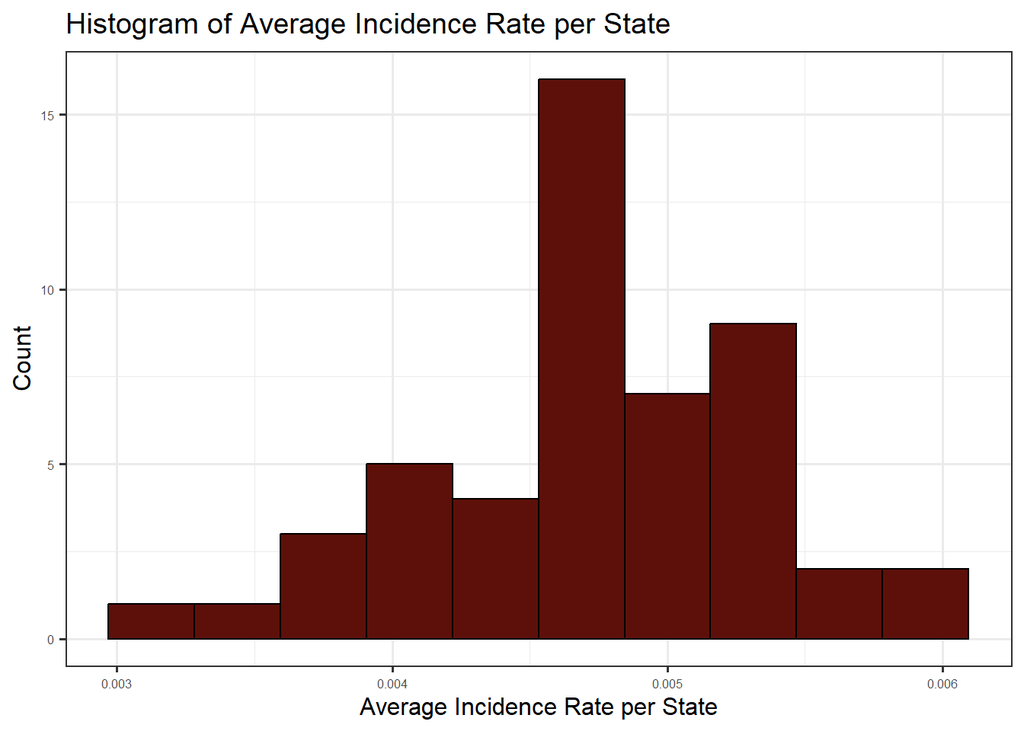

```r
#Given our summary statistics we will make plots to visualize our distribution of the Mean Incidence Rate per State
OverallData %>%
  group_by(State) %>%
  summarise(MeanIncidenceRate=mean(IncidenceRate,na.rm = TRUE)) %>%
ggplot(., aes(x=MeanIncidenceRate))+
  geom_histogram(bins = 10,fill="#5D100A",color="black")+
  theme_bw(base_size=12,base_family='Arial')  +
  theme(axis.text.y =  element_text(size = 6, family = "Arial")) +
  theme(axis.text.x =  element_text(size = 6, family = "Arial")) +
  labs(x="Average Incidence Rate per State", y="Count", title="Histogram of Average Incidence Rate per State")
```

```r
ggsave("histIncidenceRate.png", units="in", width=5, height=4)
```

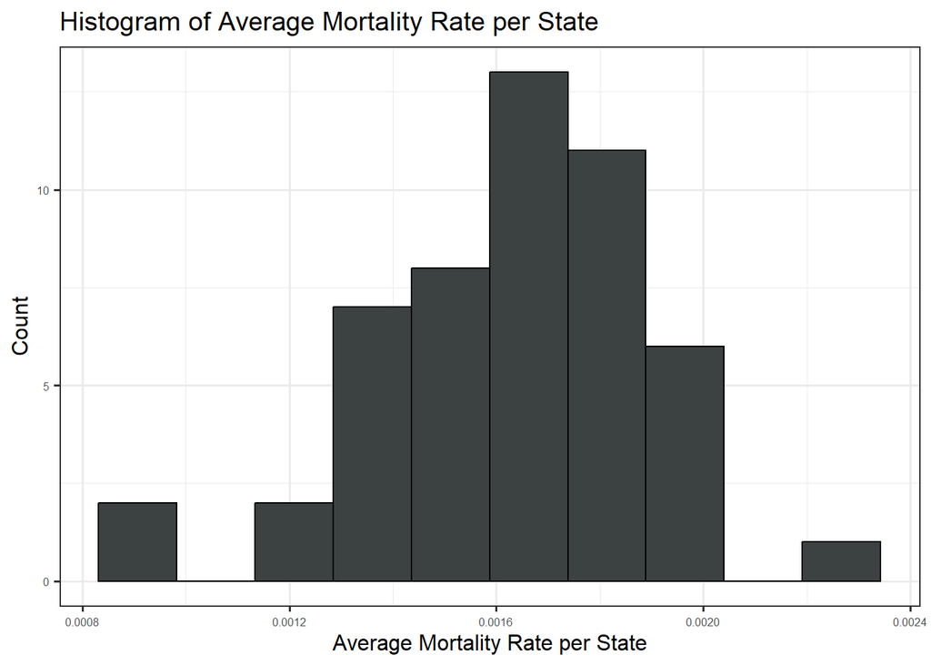

```r
# Visualize our distribution of the Mean Mortality Rate per State
OverallData %>%
  group_by(State) %>%
  summarise(MeanMortalityRate=mean(MortalityRate,na.rm = TRUE)) %>%
ggplot(., aes(x=MeanMortalityRate))+
  geom_histogram(bins = 10,fill="#3C4142",color="black")+
  theme_bw(base_size=12,base_family='Arial')  +
  theme(axis.text.y =  element_text(size = 6, family = "Arial")) +
  theme(axis.text.x =  element_text(size = 6, family = "Arial")) +
  labs(x="Average Mortality Rate per State", y="Count", title="Histogram of Average Mortality Rate per State")
```

```r
ggsave("histMortalityRate.png", units="in", width=5, height=4)
```

### Subsetting of High Incidence Rate and High Mortality Rate States

#### Timeseries Analysis

```r
# Given our distribution of the data we want to take a closer look at the States that have mean Incidence and Mortality Rates greater than the mode

#This will identify states that match the thresholds set

OverallData %>%
  group_by(State) %>%
  summarise(MeanIncidenceRate=mean(IncidenceRate,na.rm = TRUE),
            MeanMortalityRate=mean(MortalityRate,na.rm = TRUE)) %>%
  filter(MeanIncidenceRate >= 0.00525 & MeanMortalityRate >= 0.002)
```

```
## # A tibble: 2 × 3
##   State         MeanIncidenceRate MeanMortalityRate
##   <chr>                     <dbl>             <dbl>
## 1 Maine                   0.00587           0.00203
## 2 West Virginia           0.00580           0.00220
```

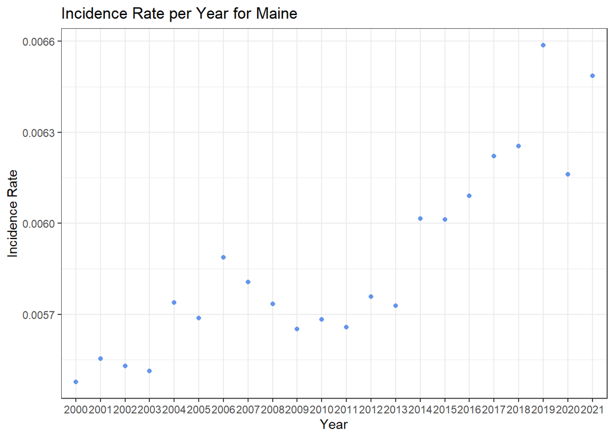

```r
#Given that Maine and West Virigina fit the criteria we first plot a graph showing how the Incidence rate has change over time for Maine.

ggplot(OverallData[OverallData$State == "Maine",],aes(x=Year,y=IncidenceRate)) +
  geom_point(col="cornflowerblue")+
  theme_bw()+
  labs(x="Year", y="Incidence Rate", title="Incidence Rate per Year for Maine")
```

The scatter graph for Maine demonstrates that since 2000, the incidence rate has gone up, however, not at a steady rate. Between the years of 2011 and 2019, the incidence rate rose and before dropping drastically during 2020. In terms of other statistics, the highest incidence rate was recorded in 2019, while the lowest rate was recorded in 2000.

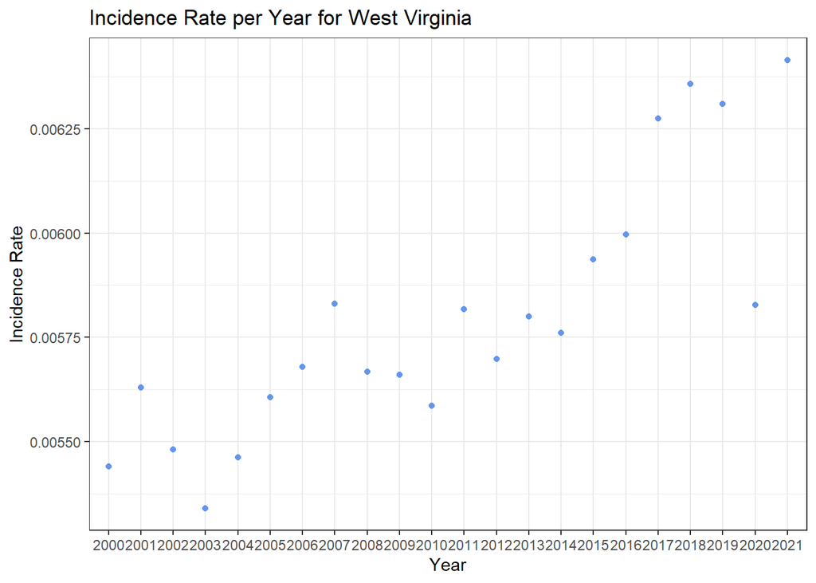

```r
#Plot a graph showing how the Incidence rate has change over time for West Virginia

ggplot(OverallData[OverallData$State == "West Virginia",],aes(x=Year,y=IncidenceRate)) +
  geom_point(col="cornflowerblue")+
  theme_bw()+
  labs(x="Year", y="Incidence Rate", title="Incidence Rate per Year for West Virginia")
```

Similar to the scatter graph for the incidence rate for Maine, the incidence rate in West Virginia, has risen since 2000, however, without a stable trend. The highest rate was recorded in 2021, while the lowest was recorded in 2003.

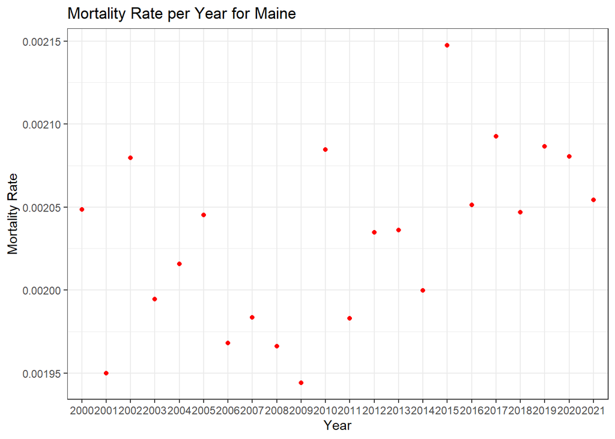

```r
#Plot a graph showing how the Mortality rate has change over time for Maine

ggplot(OverallData[OverallData$State == "Maine",],aes(x=Year,y=MortalityRate)) +
  geom_point(col="red")+
  theme_bw()+
  labs(x="Year", y="Mortality Rate", title="Mortality Rate per Year for Maine")
```

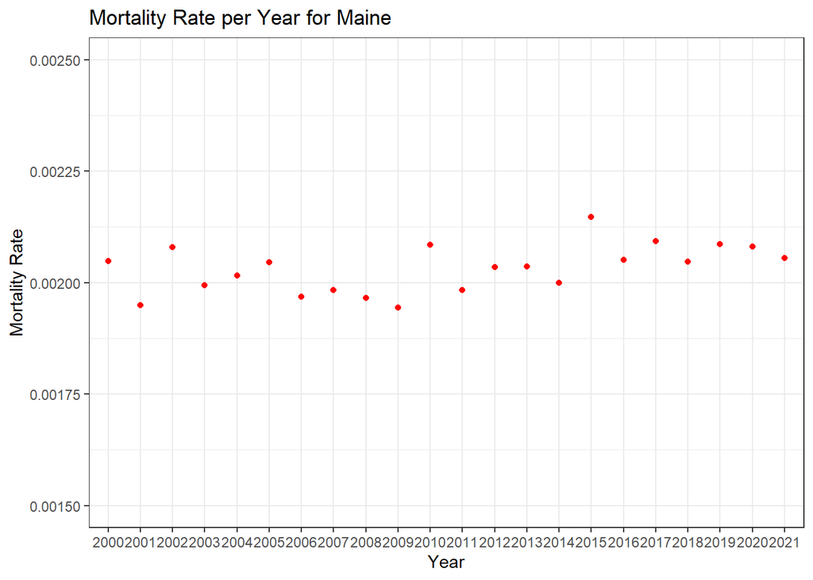

```r
#Plot with fit scales

ggplot(OverallData[OverallData$State == "Maine",],aes(x=Year,y=MortalityRate)) +
  geom_point(col="red")+
  theme_bw()+
  lims(y=c(.0015,.0025))+
  labs(x="Year", y="Mortality Rate", title="Mortality Rate per Year for Maine")
```

When initially plotted this graph gave the impression of no clear trend, however when the scales were fixed we experienced this resulting behavior in the scatter. The graph highlights a stable mortality rate around 0.0020 signifying no large change in growth over the years.

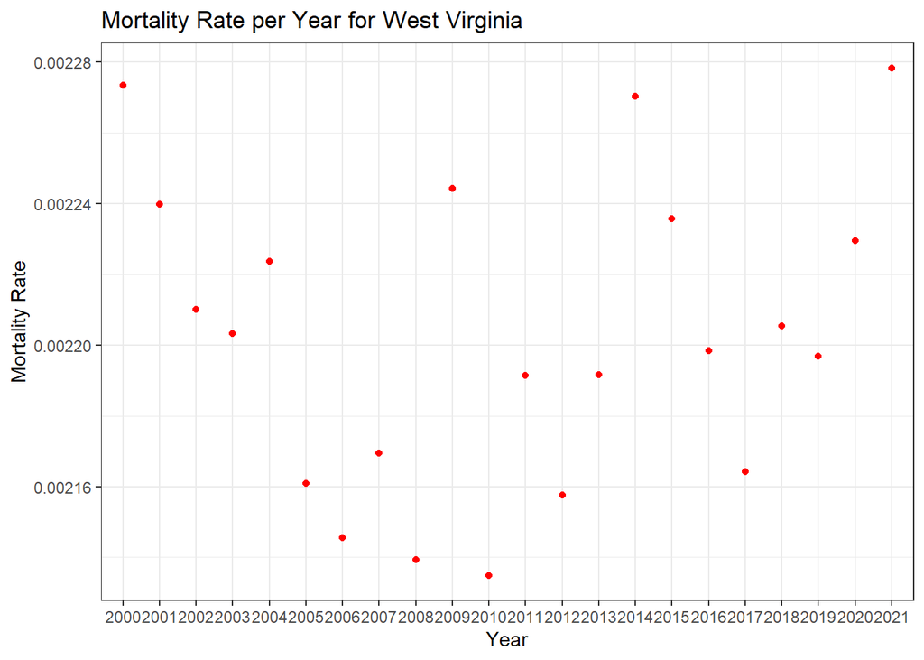

```r
#Plot a graph showing how the Mortality rate has change over time for West Virginia

ggplot(OverallData[OverallData$State == "West Virginia",],aes(x=Year,y=MortalityRate)) +
  geom_point(col="red")+
  theme_bw()+
  labs(x="Year", y="Mortality Rate", title="Mortality Rate per Year for West Virginia")
```

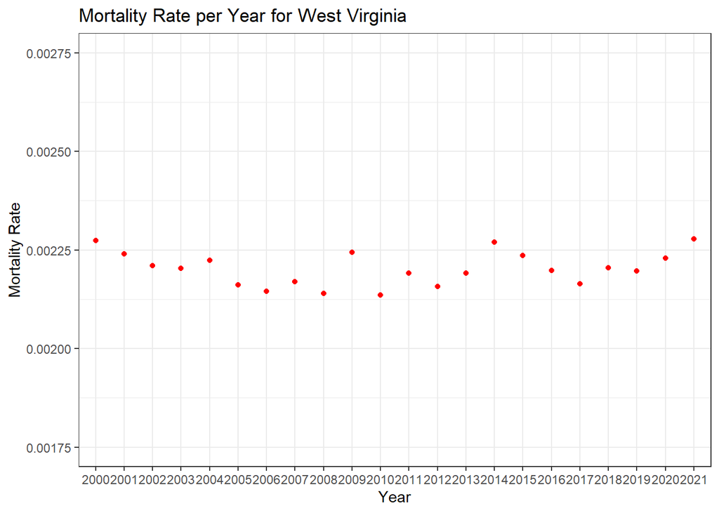

```r
#Plot with fit scales

ggplot(OverallData[OverallData$State == "West Virginia",],aes(x=Year,y=MortalityRate)) +
  geom_point(col="red")+
  theme_bw()+
  lims(y=c(.00175,.00275))+
  labs(x="Year", y="Mortality Rate", title="Mortality Rate per Year for West Virginia")
```

Similarly to the last plot, there was no clear trend but when the scales were fixed we experienced this resulting scatter. The graph highlights a stable mortality rate around 0.00225 signifying no large change in growth over the years.

### Correlation Between Incidence Rate and Mortality Rate

Inspired by the time series analysis, we wanted to see if the incidence rates and mortality rates were correlated across the years. Therefore we plotted the two variables against each other with a line of best fit to see any resulting trend.

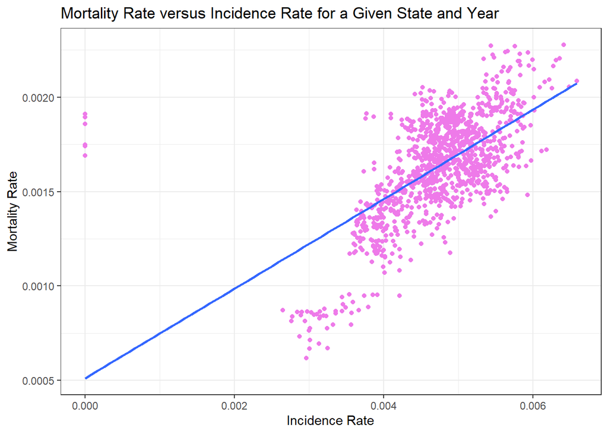

```r
#Plot a graph showing the correlation of mortality rate and incidence rate for different states and years

ggplot(OverallData,aes(x=IncidenceRate,y=MortalityRate)) +
  geom_point(col="orchid2")+
  geom_smooth(method=lm, formula = y ~ x,se=F)+
  theme_bw()+
  labs(x="Incidence Rate", y="Mortality Rate", title="Mortality Rate versus Incidence Rate for a Given State and Year")
```

The scatter plot illustrates a clear positive correlation, that indicates that as the incidence rate increases, the mortality rate tends to rise as well. Most of the data points are clustered within the higher range of values, with some outliers at the lower range of the incidence rate.

## Conclusion and Further Analysis

As evident throughout our exploratory journey, there are a lot of interesting analytical opportunities to dive into as we proceed with this project that specifically aims to explain these discrepancies. An interesting observation was that Utah has the lowest incidence and mortality rate across all states in the USA. On the other hand, Maine and West Virginia seem to fare the worst in terms of incidence and mortality rates across the USA. Moving forward, we should explore any commonalities between the states that potentially contribute to heightened incidence and mortality rates. This could entail breaking down the prevalence of different cancer types in Utah and comparing that to Maine and West Virginia’s prevalence of different cancer types. If and once a distinction is found, potential reasons to mitigate the incidence of any cancer types that may be causing the differences in rates should be explored.

## Bibliography

Bureau, U. C. (2021a, October 8). State intercensal tables: 2000-2010. Census.gov. https://www.census.gov/data/tables/time-series/demo/popest/intercensal-2000-2010-state.html Bureau, U. C. (2021b, October 8). State population by characteristics: 2010-2019. Census.gov. https://www.census.gov/data/tables/time-series/demo/popest/2010s-state-detail.html Bureau, U. C. (2024, November 25). State population by characteristics: 2020-2024. Census.gov. https://www.census.gov/data/tables/time-series/demo/popest/2020s-state-detail.html USAFacts. (2024, July 29). US cancer rates and trends: How have cancer rates and mortality changed over time? https://usafacts.org/articles/how-have-cancer-rates-changed-over-time/ Emory Libraries Resources Terms of use. Emory Libraries Resources Terms of Use - Emory University Libraries. (n.d.). https://data-sagepub-com.proxy.library.emory.edu/dataset?view=AA8BXQAAgADcAQAAAAAAAAAA3_zMslwIJ8Ve1X%24GFkbpBG2ii7wZFl2tiSNB4wcDRmeLoNKyWPVjgshN8S8Z5mg0W2zzYLcKl_iA_E5Fr1nE1D3MK0o24_d2d9f%247%24HZHyY_rm2ROPdzfEopau_r9951dnu1QxrUK7zQ54EfKAuk8griSNqdu0ow%24awcc_sdj4dueEEh_S3WpuXwtIGDSdEWFWELMxev_iZo7B5M7xJIwVA2VebjQD9VGTdSCFKKYX3EM1NjOqz35ku_8ia6q1WWdXbXMOTU Emory Libraries Resources Terms of use. Emory Libraries Resources Terms of Use - Emory University Libraries. (n.d.-a). https://data-sagepub-com.proxy.library.emory.edu/dataset?view=AA8BXQAAgADcAQAAAAAAAAAA3_zMslwIJ8Ve1X%24GFkbpBG2ii7wZFl2tiSNB53m3ZXMlw7uqekbp__CdpXcXPke58f2QDpezb1Y9EnkU6X4rM4FMdb0hw0CtCXBthd0DispXtw4usljYdpD5JKa1pfSeepLlxmv8TGyevGuQl0D%24UrSqfMdEW4TJDhRaWo18gyLM_lN4mkIpA_T10vrTfPucxbZPctEiEpGfGgKZ5a9NDEH1FY1ffEbfPbgbOaKvBqSjioWiIrJRpc2vmNM1AHzSalnhmyg